# Red Wine Quality

Justin Brown

January 10, 2018

# Red Wine Quality by Justin Brown

# Data Set: Red Wine Quality

(Reference: http://www.sciencedirect.com/science/article/pii/S0167923609001377?via%3Dihub)

As a wine enthusiast, it often intrigues me the number of adjectives that wine experts use to describe different wines. And then for those experts to masterfully sort through the myrad of flavor components and arrive at a quality rating is at the same time baffling as it is astonishing, when multiple experts come to agree that the same wine has the same level of quality. To my novice tastes, I am often embarrased to admit that I can’t discern between a 3 and an 8.

This data set contains 1599 independent observations across 13 variables. Citing from the notes with this data set, the variables described are:

1 - fixed acidity (tartaric acid - g / dm^3)

2 - volatile acidity (acetic acid - g / dm^3)

3 - citric acid (g / dm^3)

4 - residual sugar (g / dm^3)

5 - chlorides (sodium chloride - g / dm^3

6 - free sulfur dioxide (mg / dm^3)

7 - total sulfur dioxide (mg / dm^3)

8 - density (g / cm^3)

9 - pH

10 - sulphates (potassium sulphate - g / dm3)

11 - alcohol (% by volume)

Output variable (based on sensory data):

12 - quality (score between 0 and 10)

I am anxious to see which (if any) of these variables ultimately come together to determine quality rating.

# Univariate Plots Section

First up is a general overview of the data. A quick look at the first few rows to see what values are there to work with followed by a summary of each variable.

```
##   X fixed.acidity volatile.acidity citric.acid residual.sugar chlorides
## 1 1           7.4             0.70        0.00            1.9     0.076
## 2 2           7.8             0.88        0.00            2.6     0.098
## 3 3           7.8             0.76        0.04            2.3     0.092
## 4 4          11.2             0.28        0.56            1.9     0.075
## 5 5           7.4             0.70        0.00            1.9     0.076
## 6 6           7.4             0.66        0.00            1.8     0.075
##   free.sulfur.dioxide total.sulfur.dioxide density   pH sulphates alcohol
## 1                  11                   34  0.9978 3.51      0.56     9.4
## 2                  25                   67  0.9968 3.20      0.68     9.8
## 3                  15                   54  0.9970 3.26      0.65     9.8
## 4                  17                   60  0.9980 3.16      0.58     9.8
## 5                  11                   34  0.9978 3.51      0.56     9.4
## 6                  13                   40  0.9978 3.51      0.56     9.4
##   quality
## 1       5
## 2       5
## 3       5
## 4       6
## 5       5
## 6       5
```

```
##  fixed.acidity   volatile.acidity  citric.acid    residual.sugar
##  Min.   : 4.60   Min.   :0.1200   Min.   :0.000   Min.   : 0.900
##  1st Qu.: 7.10   1st Qu.:0.3900   1st Qu.:0.090   1st Qu.: 1.900
##  Median : 7.90   Median :0.5200   Median :0.260   Median : 2.200
##  Mean   : 8.32   Mean   :0.5278   Mean   :0.271   Mean   : 2.539
##  3rd Qu.: 9.20   3rd Qu.:0.6400   3rd Qu.:0.420   3rd Qu.: 2.600
##  Max.   :15.90   Max.   :1.5800   Max.   :1.000   Max.   :15.500
##    chlorides       free.sulfur.dioxide total.sulfur.dioxide
##  Min.   :0.01200   Min.   : 1.00       Min.   :  6.00
##  1st Qu.:0.07000   1st Qu.: 7.00       1st Qu.: 22.00
##  Median :0.07900   Median :14.00       Median : 38.00
##  Mean   :0.08747   Mean   :15.87       Mean   : 46.47
##  3rd Qu.:0.09000   3rd Qu.:21.00       3rd Qu.: 62.00
##  Max.   :0.61100   Max.   :72.00       Max.   :289.00
##     density             pH          sulphates         alcohol
##  Min.   :0.9901   Min.   :2.740   Min.   :0.3300   Min.   : 8.40
##  1st Qu.:0.9956   1st Qu.:3.210   1st Qu.:0.5500   1st Qu.: 9.50
##  Median :0.9968   Median :3.310   Median :0.6200   Median :10.20
##  Mean   :0.9967   Mean   :3.311   Mean   :0.6581   Mean   :10.42
##  3rd Qu.:0.9978   3rd Qu.:3.400   3rd Qu.:0.7300   3rd Qu.:11.10
##  Max.   :1.0037   Max.   :4.010   Max.   :2.0000   Max.   :14.90
##     quality
##  Min.   :3.000
##  1st Qu.:5.000
##  Median :6.000
##  Mean   :5.636
##  3rd Qu.:6.000
##  Max.   :8.000
```

The following set of plots will explore each of the variables independently to understand each a little better.

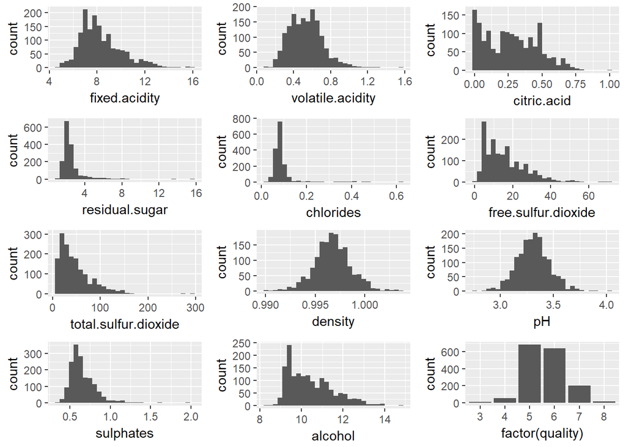

# Univariate Analysis

Consistent with the notes from the authors, the median wine quality from the selection is 6 with a mean of 5.6. The authors note that this is an “ordered not balanced” data set, “(e.g. there are munch more normal wines than excellent or poor ones)” Also, relatively normally distributed variables appear to be related to acidity (both fixed and volatile), density and pH. The remaining variables show longer tail tendencies, with some tails longer than others. Specifically, Sugar, Chlorides, Sulphates and Sulfur Dioxide (both free and total) are all particularly concentrated at the low end of the scale. Finally, Citric Acid and Alcohol content show negative, almost linear trends as one moves from the lower end to the higher end of the scale.

Because of the tidyness of this data, no additional clean up is required. I am instantly compelled to analyze whether any of the clear patterns present in the variable data lead to corrolations in the quality ratings. Also, of interest, are any correlations between these chemical variables. Perhaps they all act independently depending on the wine maker’s whim, or perhaps decisions by the wine maker in one area of chemical make-up result in correlated attributes in other areas represented.

# Bivariate Plots and Analysis

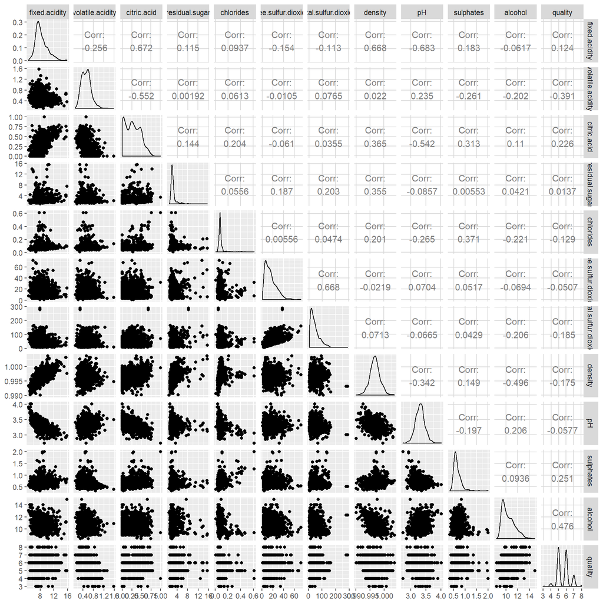

Since correlation is most significant when r values are closer to +/- 1, and least significant when r values are closer to 0, the first points of interest are those correlations with an absolute value closest to 1. Also, as the main point of this analysis is quality prediction, seeing which variables seem most correlated with quality is the initial thrust for this section.

The most relevant quality correlation of any variable collected is alcohol content, having an r value of 0.476, very near the “rule of thumb” for a significant correlation (which is r values from 0.5 to 1.0). However, while this correlation is not quite at 0.5, it is clear that alcohol content alone does not determine the quality. Let’s take a closer look at this relationship.

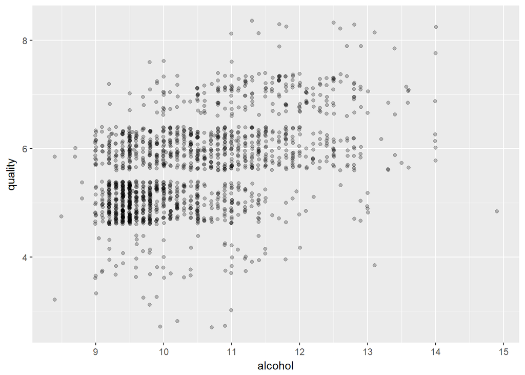

Due to the outliers on the alcohol levels, I will use a log10 transform on the x axis to normalize the data to make patterns more visually obvious.

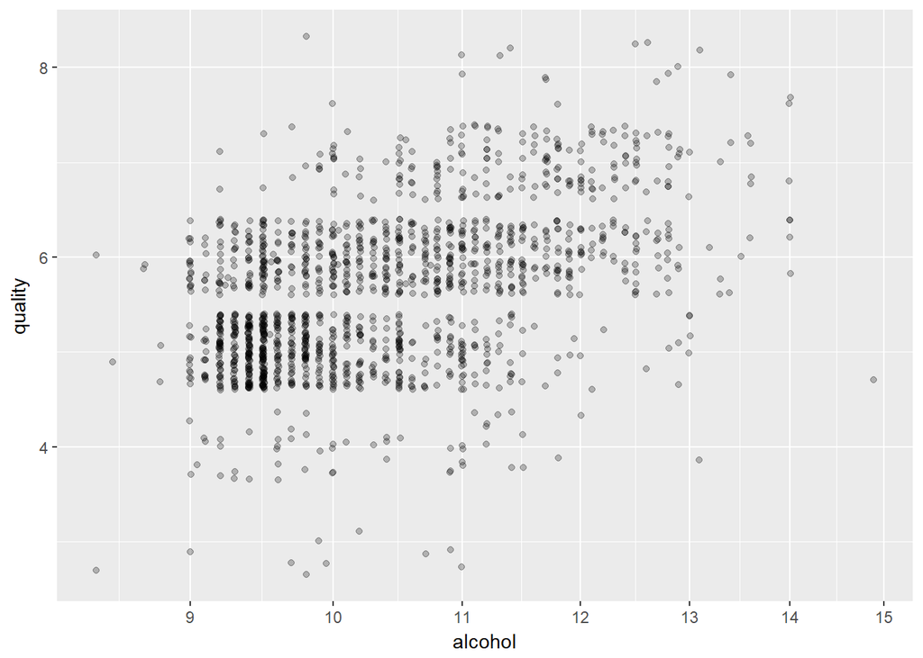

Because these outliers are not far beyond the norm, this transform is minimally useful.

Let’s analyze three other variables that have a notable (though far from significant) correlation to quality, especially when compared to the correlations of the remaining variables. These variables are volatile.acidity, sulphates and citric acid (in order of apparent correlation). The r values for these variables when compared to quality are -0.391, 0.251 and 0.226, respectively. Let’s see these charts together.

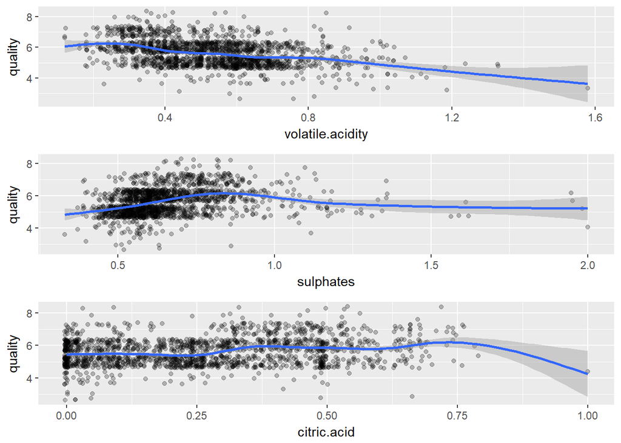

While the correlation between citric.acid and quality is, visually, confirmed to be weak, interestingly (with the exception of some outliers on the high end of each scale) both volatile.acidity and sulphates appear to have some more significant correlations in the lower to middle part of each scale. Let’s take another look at these charts without the outliers. Using box plots, let’s determine where we should set the limits for deterimining the outliers.

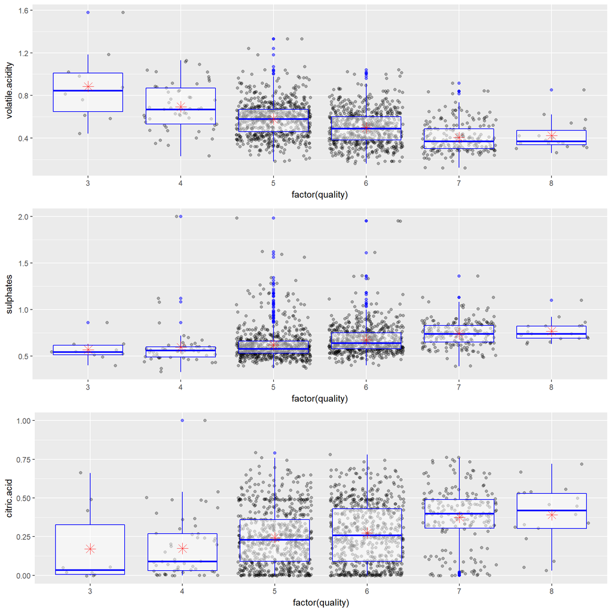

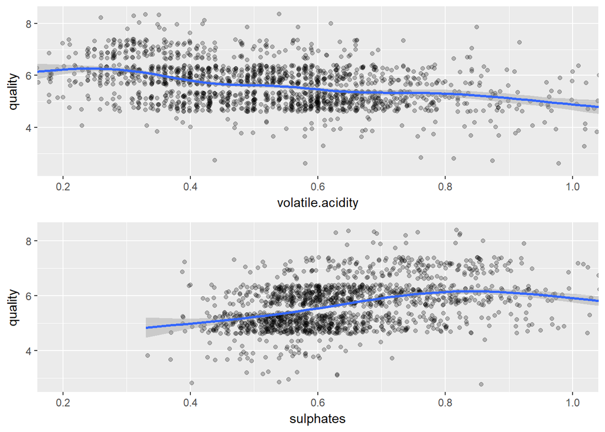

Another way to minimize the impact of the outliers in the graphs is to transform the x axis using a log10 scale.

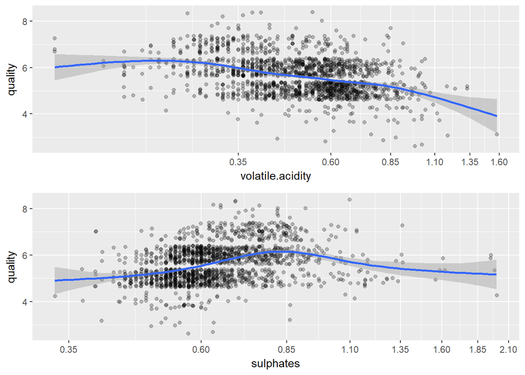

By eliminating the impacr of the outliers, the correlations appear much more similar to the alcohol correlation evaluated previously. Using this subset, I will look at the recomputed correlations.

```
##
##  Pearson's product-moment correlation
##
## data:  rw_subset_va$volatile.acidity and rw_subset_va$quality
## t = -15.379, df = 1559, p-value < 2.2e-16
## alternative hypothesis: true correlation is not equal to 0
## 95 percent confidence interval:
##  -0.4052646 -0.3190794
## sample estimates:
##       cor
## -0.362948
```

```
##
##  Pearson's product-moment correlation
##
## data:  rw_subset_sul$sulphates and rw_subset_sul$quality
## t = 16.805, df = 1539, p-value < 2.2e-16
## alternative hypothesis: true correlation is not equal to 0
## 95 percent confidence interval:
##  0.3507252 0.4351437
## sample estimates:
##       cor
## 0.3937644
```

Although the outliers visually appeared they may be affecting both correlations, Pearson’s test shows that eliminating the outliers only improves one of the two correlations. And it is a fairly significant increase from 0.251 to 0.394 when analyzing sulphates.

The relationship between citric.acid and volatile.acidity (r = -0.552) initially escaped scrutiny. As both are a measure of acidity, is would not be unexpected to see correlation. However, what was interesting is that these variables are negatively correlated, not positively as one might expect based on title alone. Further, since both of these variables raised interest in terms of their correlation to quality, at least a surface level review is warranted. After all, if one of these measures would be easier for a wine maker to control than the other, assuming their high correlation to each other and relatively higher correlation to quality as compared to other variables, this information may be useful in driving the proper make-up of a high quality wine.

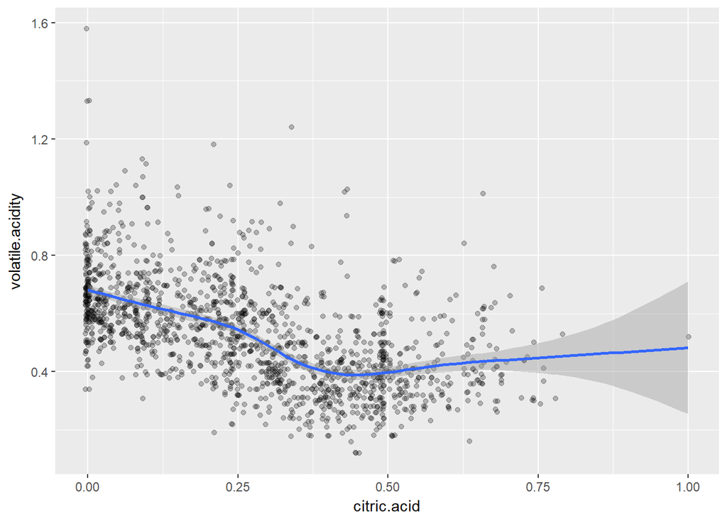

Based on this relationship and the corresponding relationships to quality, if one could more easily control for citric.acid content, higher levels of citric acid will drive lower levels of volatile acidity, both of which appear more strongly correlated with wines that rate higher on the quality scale. The inverse is true if a wine maker could more easily control volatile acidity. That is lower levels of volatile acidity correlate with higher levels of citric acid, which in turn correlates to wines that tend to rate higher on the quality scale.

Correlations between the variables other than quality do exist, however, due to the relativity of the quality measured, these correlations do not seem interesting initially and will fall outside of this analysis. They may, however, be worth a further look in a more extensive review. Following is a list of some of these correlations with a brief mention of the rationale for their exclusion in this review: * ph and fixed.acidity (r = -0.683) - While this is the highest correlation observed between any two variables in the data set, the correlation is not illogical. pH is a measure of acidity (or alkalinity) and lower pH values are indicative of higher levels of acidity, therefore a relatively high negative correlation would be expected. * total.sulfur.dioxide and free.sulfur.dioxide (r = 0.668) - Because both of these data points relate to sulfur dioxide, a strong positive correlation is not illogical. * density and fixed.acidity (r = 0.668) - This relationship is more interesting, however, as neither density nor fixed.acidity seem to have a high correlation to the quality (which is the focus of this analysis), this relationship will not be explored further.

# Multivariate Plots Section

The following plots investigate more complex relationships between the variables highlighted above.

First, I will look at the relationship between citric acid levels related to sulphates.

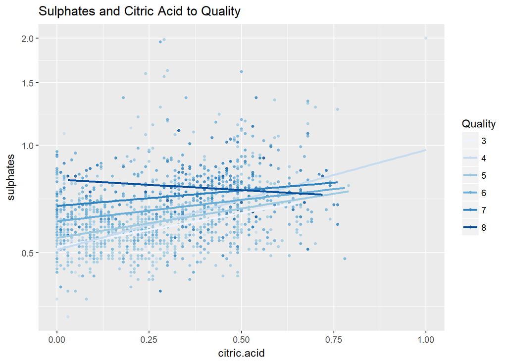

In analyzing these charts, if citric acid had an impact on quality at different sulphate levels, interestingly, for wines recieving the highest quality rating (8), the relationship between sulphates indicates an inverse relationship (i.e. higher sulphates and lower citric levels do will in this quality group, and lower sulphates paired with higher citric acid levels tend), though the line is nearly flat. However, for all other quality ratings the relationship is opposite that of wines in the highest quality category. Based on this sample, one wishing to increase the chance of an 8 rating would want to keep citric acids lower and sulphates slightly higher, as this characteristic appears to have resulted in higher 8 ratings.

The next chart will reverse the citric acid and sulphate values in the above chart. Because there was no obvious correlation in the above chart, I would expect that I will not see an obvious correlation by reversing these conditions, however, my inquisitive mind wants to see.

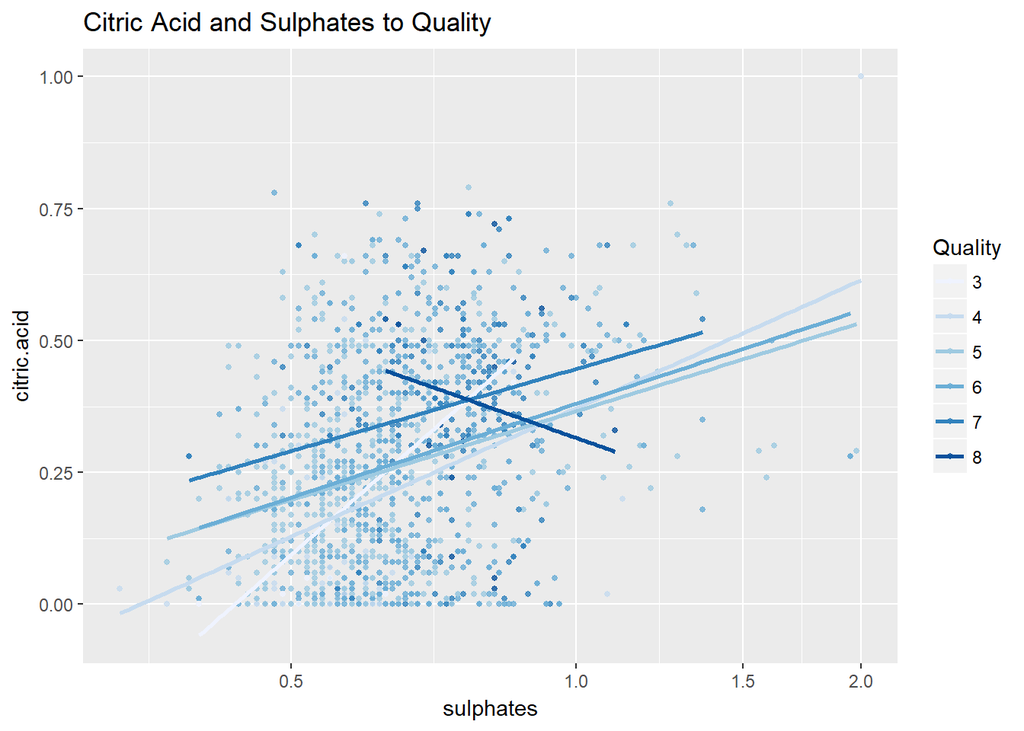

Again, in analyzing these charts, it is clear that the impact of varying citric acid and sulphates in those wines that receive the highest ratings is opposite of the impact of these variables relationship in wines that recieved every other rating.

It does appear in both of these charts, that the highest concentration of wines receiving the highest rating had citric acit levels between 0.25 and 0.5 and sulphate levels aroune 0.75.

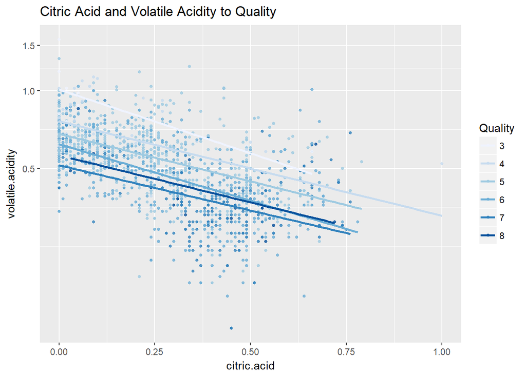

The last view I will look at is the impact of citric acid on quality at varying levels of alcohol content, focusing on the most common alcohol levels between 9 and 14.

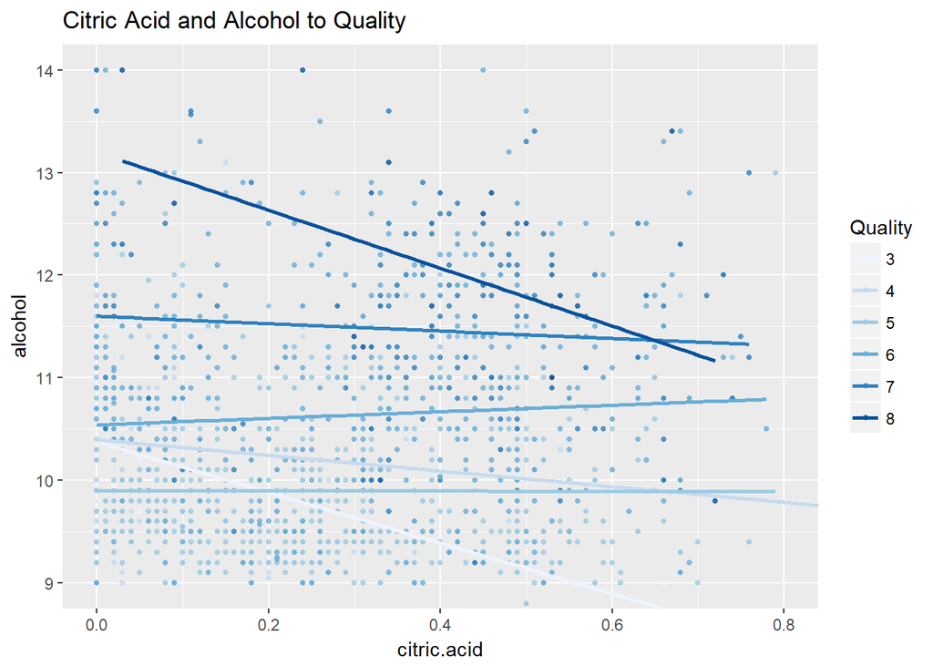

Here, in the lowest rated wines and the highest rated wines, the relationship between alcohol and citric acid is an inverse relationship, while in every other category of wine the relationship is nearly flat.

# Multivariate Analysis

# Final Plots and Summary

In concluding this exploration, the following three plots appear to show the strongest relationships between quality and other variables.

### Plot One

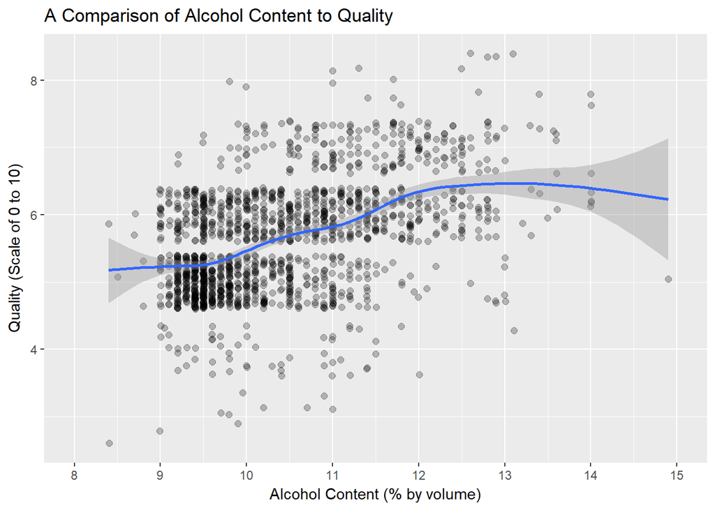

### Description One

For my initial summary plot, I go all the way back to one of the first plots in this analysis. At first, this plot did not seem so relevant in light of the apparent lack of a strong correlation and the evidince of stronger correlations between quality and other variables. However, in the end, within this sample, controlling for alcohol content actually apears to be one way to achieve a higher possibility of a good rating.

Specifically, across 1599 observations, all oservations between around 13.25% and 14% alcohol achieved ratings of 6 or higher. This seems to be a sweet spot at which, if controlled, can provide a strong opportunity for quality at a a higher level. Further very few wines had an alcohol content of lowere than 9% and of those, none achieved a rating above 6. This is territory to avoid.

For commodity wines, alcohol content between 9 and 13 will put you in the middle of the pack.

### Plot Two

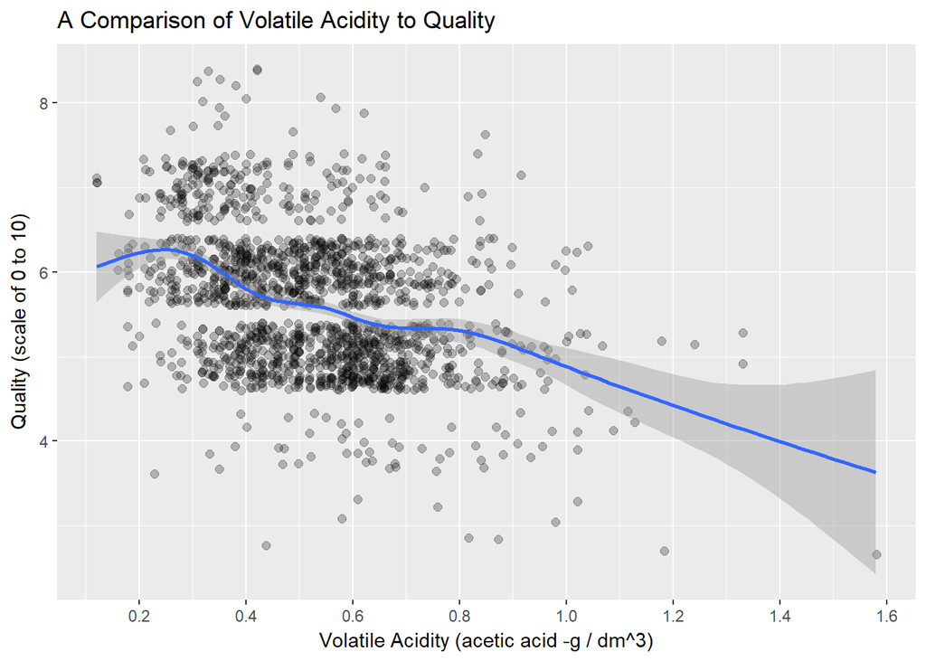

### Description Two

This is one of the more obvious ways to improve the chances of a higher quality rating, or more specifically, how to avoid a mediocre or low rating. There is a very high concentration of 7 and 8 quality ratings between 0.2 and 0.4.  
While evidence of lower ratings also exist in this range, the likelihood of achieving a 7+ rating is significantly reduced above a volitile acidity level of 0.45.

### Plot Three

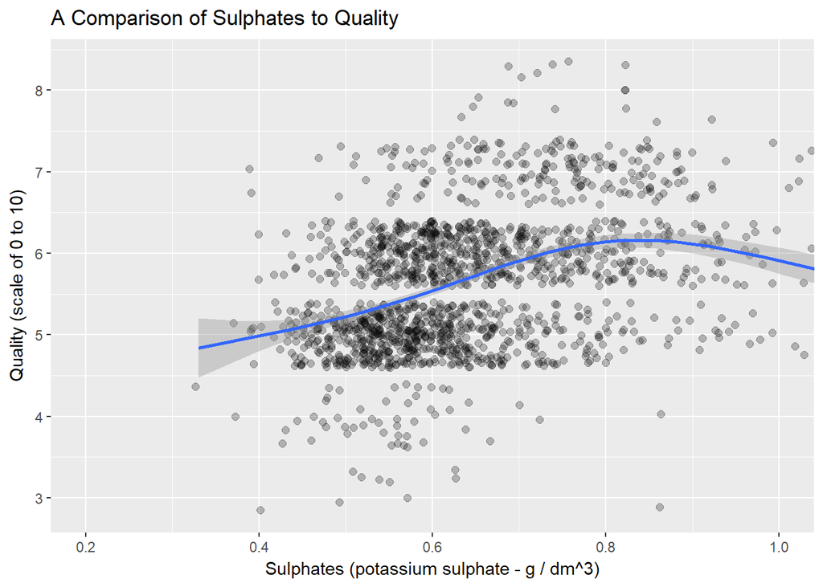

### Description Three

Lastly, the comparison between sulphates and quality identifies a target range to aim for in an attempt to improve your rating. No 8 rated wines had a sulphate level less than 0.6 and only few 7 rated wines had a level below 0.5.

Once again, controlling sulphates to greater than 0.5 doesn’t guarantee a 7+ rating… there are many 5 and 6 rated wines in this range as well. But the tasters appear to favor sulphates between 0.5 and 0.9 in the wines that recieved the more favorable ratings.

# Reflection

Reflecting on the exploratory analysis above, I am left to wonder if the rating a wine recieves might be as much a factor of the taster as any combination of qualities. That said, there do seem to be a few factors (volatile acidity, sulphates and alcohol content) for which, if one places a new wine in favorable ranges, tend to gain favorale quality ratings as a result.

In order to better understand the impact of the individual wine judge, it would be good to have a panel of ratings for each wine, with the same panel of judges performing all observations. One could then identify a balanced observation controlling for different taste preferences, as well as identify if certain individuals tend to have unique and consistent taste preferences across a range of observations.

In the end, I know what I would target for a wine creation that I hoped would appeal to wine tasters:

- Alcohol between 13% and 14%
- Volatile Acidity between 0.2 and 0.4
- Sulphates between 0.7 and 0.9